# Reproducible research: Project1

## Third part

Before imputing missing values, let’s first check how they are distributed in our data set:

```r
colSums(is.na(data_raw1))
```

```
##    steps     date interval
##     2304        0        0
```

```r
data_raw <- data_raw1
data_raw$steps[which(is.na(data_raw$steps))] <- median(data_raw$steps,na.rm = TRUE)
```

After this, we construct our plot in the same way as the first one.

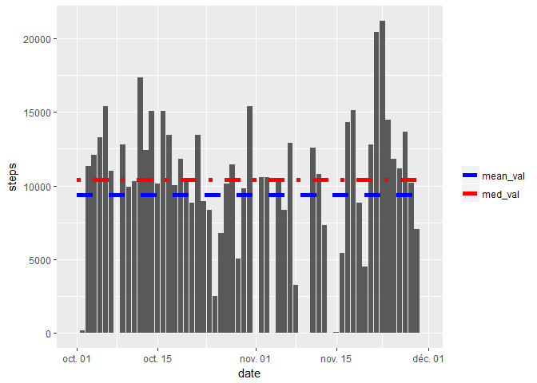

```r
sp <- ggplot(data = data_raw,
       aes(date, steps)) +
        stat_summary(fun.y = sum,
                     geom = "bar")

data_raw_sum<- data_raw %>%
        group_by(date) %>%
        mutate(total=sum(steps))

mean_val <- mean(data_raw_sum$total)
med_val <- median(data_raw_sum$total)

sp    +
 geom_line( aes(y =  mean_val,  color = "mean_val"), linetype="dashed", size=2)+
 geom_line(aes(y=med_val,color = "med_val")  ,linetype="dotdash", size=2)+
        scale_color_manual(name = "",
                           values = c("mean_val" = "blue", "med_val" = "red"))
```

The plot shows that imputing NA values gives different results than when we completely discard them.

## Fourth part

To see the difference between weekdays and weekends, we construct a vector that labels weekend as “weekend” and weekdays as “weekdays” and we add it to our data set.

```r
weekend=ifelse(is.weekend(data_raw$date),"weekend","weekday")
data_raw <- ungroup(data_raw)
data_raw <- mutate(data_raw,weekend1=weekend)
```

After that, we make a plot with two facets: one for the weekdays, and the other for the weekend.

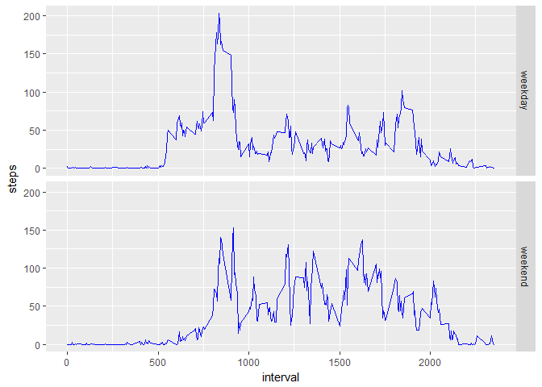

```r
ggplot(data = data_raw,
       aes(interval, steps,group=weekend1)) +
        stat_summary(fun.y = mean,geom = "line",color="blue")+ facet_grid( data_raw$weekend1~.)
```

We see that the activity is different between these two.